# COVID-19 in VIETNAM

Joey Vo

Last edited 2021-09-14

## **Project overview**

This project uses data collected in real-time from the [`Vietnamese Government COVID-19's portal`](https://ncov.vncdc.gov.vn/) to demonstate analyses related to the COVID-19 figures in Vietnam. Data has been continuously updated since 2021-04-27.

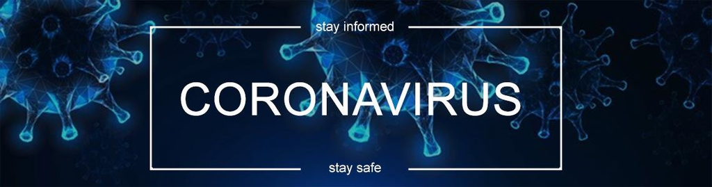

### Part 1: NATIONAL TRENDLINE & TOP CITIES WITH MOST CASES

The first Json file collected from [this API](https://ncov.vncdc.gov.vn/v2/vietnam/by-current?start_time=2021-04-27) contains daily number of COVID-19 cases recorded in each province since 27/04/2021

```r
#Load the jsonfile into R's dataframe
url <- "https://ncov.vncdc.gov.vn/v2/vietnam/by-current?start_time=2021-04-27"

file <- fromJSON(url)

glimpse(file)
```

```
## Rows: 63
## Columns: 13
## $ id                        <int> 29, 61, 59, 58, 57, 56, 53, 51, 49, 48, 47, …
## $ tinh                      <chr> "Thành phố Hồ Chí Minh", "Tỉnh Vĩnh Long", "…
## $ ngay_hien_tai             <int> 0, 0, 0, 0, 0, 0, 0, 0, 0, 0, 0, 0, 0, 0, 0,…
## $ ngay_truoc_do             <int> 5446, 5, 4, 161, 18, 7, 142, 11, 1, 13, 7, 5…
## $ ngay_hom_kia              <int> 6158, 1, 7, 628, 0, 12, 93, 0, 0, 30, 12, 61…
## $ population                <int> 8993082, 1022600, 1009300, 9038600, 1766300,…
## $ ngay_lien_tiep            <int> 0, 0, 0, 0, 0, 0, 0, 0, 0, 0, 0, 0, 0, 0, 0,…
## $ ngay_lien_tiep_trong_nuoc <int> 0, 0, 0, 0, 0, 0, 0, 0, 0, 0, 0, 0, 0, 0, 0,…
## $ ca_nhiem                  <int> 301463, 2126, 1421, 12371, 763, 406, 6759, 1…
## $ ma                        <int> 79, 86, 84, 82, 46, 38, 72, 94, 22, 51, 49, …
## $ data                      <df[,141]> <data.frame[26 x 141]>
## $ ca_nhiem_7                <int> 44939, 16, 35, 1561, 47, 49, 997, 44, 1…
## $ tu_vong                   <int> 12095, 61, 16, 331, 12, 1, 108, 25, 0, 0, 5,…
```

As the daily record of cases by each city is nested in a dataframe within the bigger dataframe, we will need to transform the format of the dataset before performing further analysis

#### Transform the data into dataframe

```r
data_all <- data.frame()

covidData <- data.frame(cityID=integer(), cityName=character(), date= character(), value = integer())
datelist <- colnames(file$data)
for (row in 1:nrow(file)) {
  cityID <- file[row, 1]
  cityName <- file[row, 2]
  for (i in 1:length(datelist)) {
    date <- datelist[i]
    value <- file$data[row, i]
    de <- list(cityID = cityID, cityName = cityName, date = date, value = value)
    covidData = rbind(covidData, de, stringsAsFactors=FALSE)
  }
}
covidData$date <- ymd(covidData$date)
str(covidData)
```

```
## 'data.frame':    8883 obs. of  4 variables:
##  $ cityID  : int  29 29 29 29 29 29 29 29 29 29 ...
##  $ cityName: chr  "Thành phố Hồ Chí Minh" "Thành phố Hồ Chí Minh" "Thành phố Hồ Chí Minh" "Thành phố Hồ Chí Minh" ...
##  $ date    : Date, format: "2021-04-27" "2021-04-28" ...
##  $ value   : int  0 0 0 1 0 0 0 0 0 0 ...
```

#### Total daily COVID-19 cases in Vietnam

```r
totalcase <- covidData %>%
  group_by(date) %>%
  summarize(sum = sum(value))
str(totalcase)
```

```
## tibble [141 × 2] (S3: tbl_df/tbl/data.frame)
##  $ date: Date[1:141], format: "2021-04-27" "2021-04-28" ...
##  $ sum : int [1:141] 1 0 2 11 2 3 12 7 4 77 ...
```

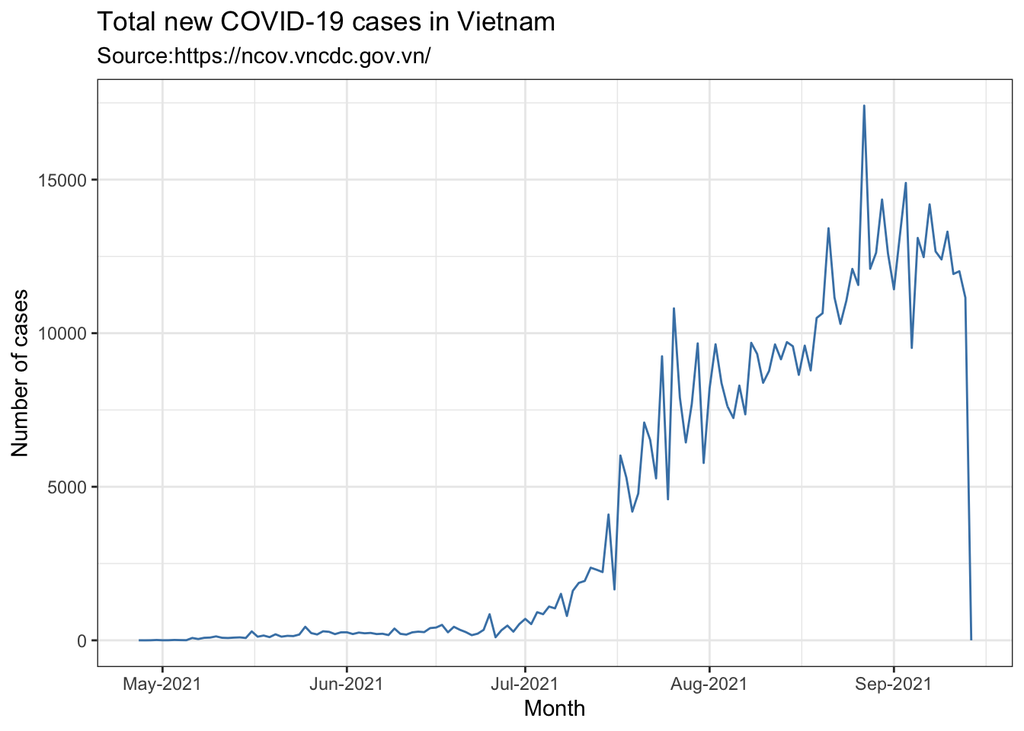

```r
ggplot(totalcase, aes(x = date, y = sum, group = 1)) +
  geom_line(color="steelblue") +
  labs(x = "Month", y = "Number of cases", title = "Total new COVID-19 cases in Vietnam", subtitle = "Source:https://ncov.vncdc.gov.vn/")  + theme_bw() + theme(panel.background = element_blank()) +
  scale_x_date(date_labels = "%b-%Y")
```

#### Top 10 cities with the most cases in the last 7 days

```r
#Preapre the data for plotting

currentdate = Sys.Date()

covidData[is.na(covidData)] = 0

top10 <- covidData %>%
  filter(date >= (currentdate -7)) %>%
  group_by(cityName) %>%
  summarize(sum = sum(value)) %>%
  arrange(desc(sum)) %>%
  head(10)
```

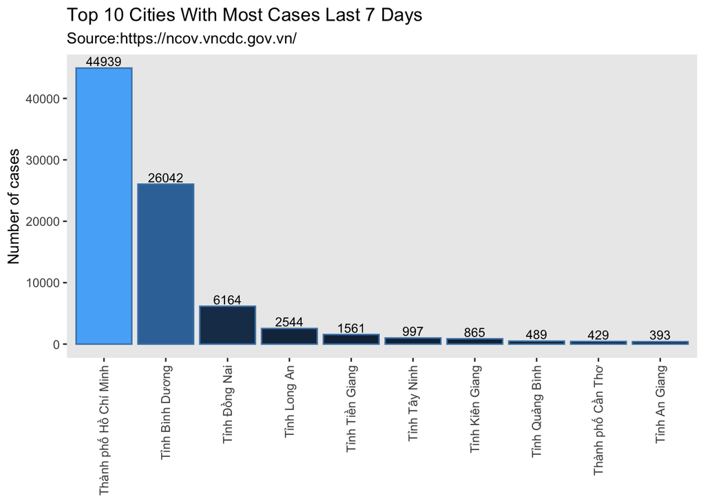

```r
ggplot(top10, aes(x = reorder(cityName, -sum), y = sum, fill = sum)) + geom_col(color="steelblue") + labs(y = "Number of cases", title = "Top 10 Cities With Most Cases Last 7 Days", subtitle = "Source:https://ncov.vncdc.gov.vn/") + theme(axis.text.x = element_text(angle = 90, vjust = 0.5, hjust=1), axis.title.x=element_blank(), legend.position = "none") +   geom_text(aes(label=sum), position=position_dodge(width=0.9), vjust=-0.25, size = 3.2) + theme(panel.grid.major = element_blank(), panel.grid.minor = element_blank())
```

### COVID-19 CASES BY GENDER & AGE

The second Json file from [this API](https://ncov.vncdc.gov.vn/v2/vietnam/dotuoi?start_time=2021-04-27) contains daily number of COVID-19 cases recorded, with details related to gender & age since 27/04/2021

```r
#Load & transform the API data

url1 <- "https://ncov.vncdc.gov.vn/v2/vietnam/dotuoi?start_time=2021-04-27"

file1 <- fromJSON(url1)

sex_age <- data.frame()

sex_age <- data.frame(sex=character(), age=character(), value = integer())
agelist <- colnames(file1$data)
agelist
```

```
## [1] "0-2"   "3-12"  "13-17" "18-65" "> 65"
```

```r
for (row in 1:nrow(file1)) {
  sex <- file1[row, 1]
  for (i in 1:length(agelist)) {
    age <- agelist[i]
    value <- file1$data[row, i]
    li <- list(sex = sex, age = age, value = value)
    sex_age = rbind(sex_age, li, stringsAsFactors=FALSE)
  }
}

str(sex_age)
```

```
## 'data.frame':    10 obs. of  3 variables:
##  $ sex  : chr  "Nam" "Nam" "Nam" "Nam" ...
##  $ age  : chr  "0-2" "3-12" "13-17" "18-65" ...
##  $ value: int  6965 25763 16564 216279 13279 6381 22875 15341 229606 22846
```

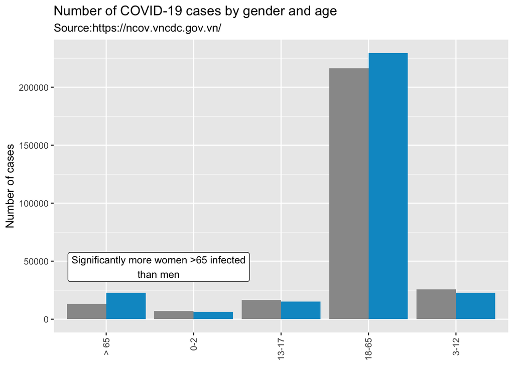

```r
#Plot
caption <- paste(strwrap("Significantly more women >65 infected than men", 40), collapse = "\n")
cbPalette <- c("#999999","#0099CC")

ggplot(sex_age, aes(x = age, y = value, fill= sex)) + geom_col(position = position_dodge()) +
labs(y = "Number of cases", title = "Number of COVID-19 cases by gender and age", subtitle = "Source:https://ncov.vncdc.gov.vn/") + theme(axis.text.x = element_text(angle = 90, vjust = 0.5, hjust=1), axis.title.x=element_blank(), legend.position = "none") +
annotate("label", x = 1.6, y = 45000, label = caption, size = 3.5) + scale_fill_manual(values=cbPalette)
```

Further analysis: Proportion of COVID-19 Cases by Gender

```r
sex_percent <- sex_age %>%
  group_by(sex) %>%
  summarize(sum = sum(value)) %>%
  mutate(total = sum(sum),
         percent = sum/total)
```

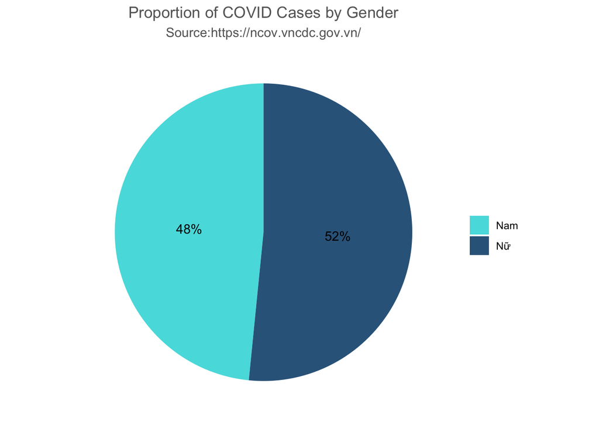

```r
# Create a basic bar
pie = ggplot(sex_percent, aes(x="", y=percent, fill=sex)) + geom_bar(stat="identity", width=1)

# Convert to pie (polar coordinates) and add labels
pie = pie + coord_polar("y", start=0) + geom_text(aes(label = paste0(round(percent*100), "%")), position = position_stack(vjust = 0.5))

# Add color scale (hex colors)
pie = pie + scale_fill_manual(values=c("#55DDE0", "#33658A", "#2F4858", "#F6AE2D", "#F26419", "#999999"))

# Remove labels and add title
pie = pie + labs(x = NULL, y = NULL, fill = NULL, title = "Proportion of COVID Cases by Gender", subtitle = "Source:https://ncov.vncdc.gov.vn/")

# Tidy up the theme
pie = pie + theme_classic() + theme(axis.line = element_blank(),
          axis.text = element_blank(),
          axis.ticks = element_blank(),
          plot.title = element_text(hjust = 0.5, color = "#666666"),
          plot.subtitle = element_text(hjust = 0.5, color = "#666666"))

pie
```

### SOURCE OF TRANSMISSIONS & DEATH RATE BY CITIES

The [third Json file](https://ncov.vncdc.gov.vn/v2/vietnam/province-type?start_time=2021-04-27) contains accumulated number of cases of COVID-19 recorded in each city, within two categories: Overseas/ Local transmission + the accummulated death figure.

```r
url <- "https://ncov.vncdc.gov.vn/v2/vietnam/province-type?start_time=2021-04-27"

file <- fromJSON(url)


glimpse(file)
```

```
## List of 2
##  $ columns:'data.frame': 5 obs. of  4 variables:
##   ..$ name : chr [1:5] "tinh" "so_ca" "tu_vong" "cong_dong" ...
##   ..$ label: chr [1:5] "Tỉnh/Thành phố" "Số nhiễm" "Số tử vong" "Số trong nước" ...
##   ..$ color: chr [1:5] "#EC7505" "#EC7505" NA NA ...
##   ..$ 0    : chr [1:5] NA NA "#eb0202" "#fac664" ...
##  $ rows   :'data.frame': 64 obs. of  5 variables:
##   ..$ tinh     : chr [1:64] "Tỉnh An Giang" "Tỉnh Bà Rịa - Vũng Tàu" "Tỉnh Bắc Giang" "Tỉnh Bắc Kạn" ...
##   ..$ so_ca    : int [1:64] 2764 3974 5831 7 264 1866 1827 905 160667 959 ...
##   ..$ cong_dong: int [1:64] 2697 3930 5828 6 263 1853 1827 892 160667 959 ...
##   ..$ nhap_canh: int [1:64] 67 44 3 1 1 13 0 13 0 0 ...
##   ..$ tu_vong  : int [1:64] 33 38 15 0 0 20 65 11 1396 8 ...
```

```r
province_data <- file[2]$rows
```

```r
#Source of infections and death figures

summary <- province_data %>%
summarize(cong_dong = sum(cong_dong), nhap_canh = sum(nhap_canh), tu_vong = sum(tu_vong))

summary1 <- transpose(summary)
summary1$type = colnames(summary)
colnames(summary1) <- c("value","type")

summary1
```

```
##    value      type
## 1 620414 cong_dong
## 2   1278 nhap_canh
## 3  15624   tu_vong
```

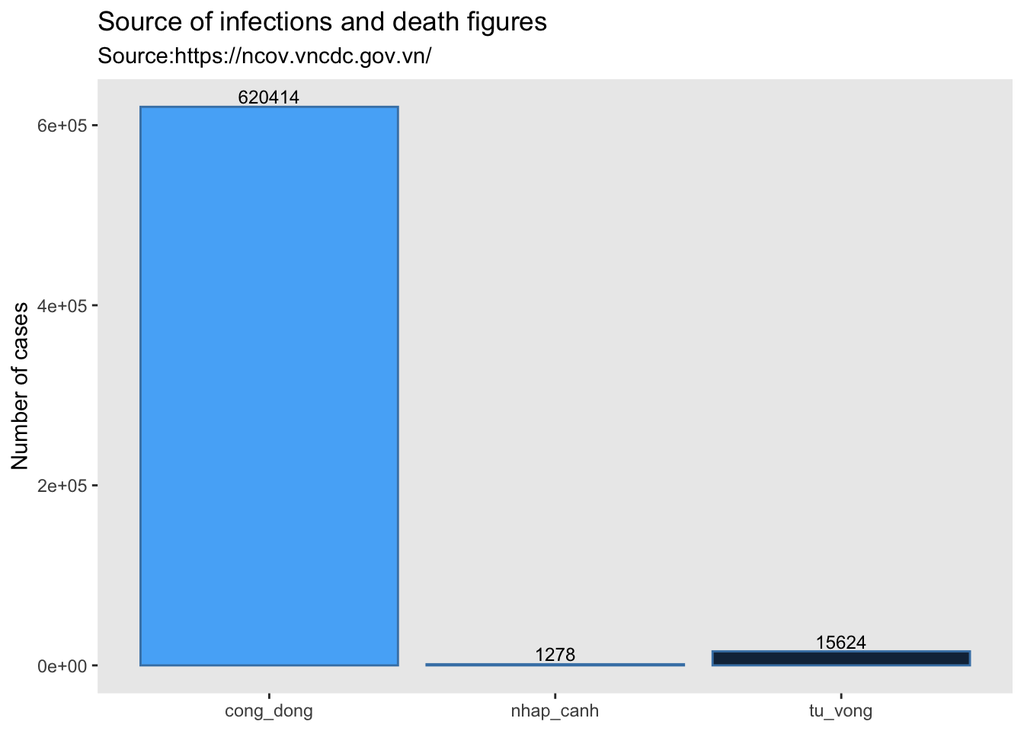

```r
#Source of infections & death figures
ggplot(summary1, aes(x= type, y = value, fill = value)) + geom_col(color="steelblue") + labs(y = "Number of cases", title = "Source of infections and death figures", subtitle = "Source:https://ncov.vncdc.gov.vn/")+
theme(axis.title.x=element_blank(), legend.position = "none") +   geom_text(aes(label=value), position=position_dodge(width=0.9), vjust=-0.25, size = 3.2) + theme(panel.grid.major = element_blank(), panel.grid.minor = element_blank())
```

As can be seen from the figure, community transmission is the critical source of COVID-19 spread in Vietnam. In addition, the death rate/ total infection is relatively low

```r
#Top 10 - Death rate of COVID -19 by cities
death_figure <- province_data %>%
mutate(death_rate = round((tu_vong *100/so_ca),2)) %>%
arrange(desc(death_rate)) %>%
head(10)
```

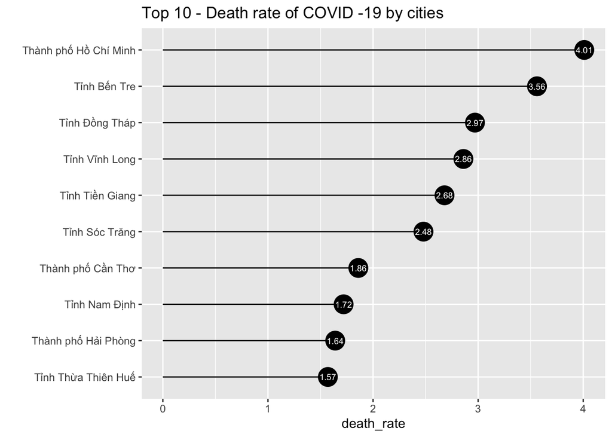

```r
ggplot(death_figure, aes(x= reorder(tinh, death_rate), y = death_rate, label = death_rate)) +
  geom_point(stat='identity', fill="white", size=7)  +
  geom_segment(aes(y = 0, x = tinh,
                   yend = death_rate,
                   xend = tinh),
               color = "black") +
  geom_text(color="white", size=2.5) +
  labs(x= "", title="Top 10 - Death rate of COVID -19 by cities") +
  coord_flip()
```

Ho Chi Minh City is both the city with the highest cases during the last 7 days and the leading city regarding the death rate/ total infections.